# Alluvial Plots in R

2023-10-04

Hello and welcome to the GG Alluvial Cheatsheet/markdown file for Rhys. SO, welcome Rhys! In case you forgotten how to modify this data, we’ll help you out here

So, a lot of this information is taken from: https://cheatography.com/seleven/cheat-sheets/ggalluvial/ so if you wanna just read that, that’s ok, but trust me this stuff is also pretty good as it will show more. The ggalluvial package is a ggplot2 extension for producing alluvial plots. In case you need to remember what an Alluvial plot is: Alluvial plots use variable-width ribbons and stacked bar plots to represent multi-dimensional or repeated measures data with categorical or ordinal variables Two types - Alluvial (Wide) Format & Lodes (Long) Format.

There are five essential components to this package: 1.AXIS: A dimension (variable) align which the data are vertically grouped at a fixed horizontal position 2.ALLUVIUM: Horizontal (x-) lines called alluvia span the width of the plot 3.STRATUM: The groups at each axis are depicted as opaque blocks called strata (columns) 4.LODE: The alluvia insersect the strata at lodes 5.FLOW: The segments of the alluvia between pairs of adjacent axes are flows

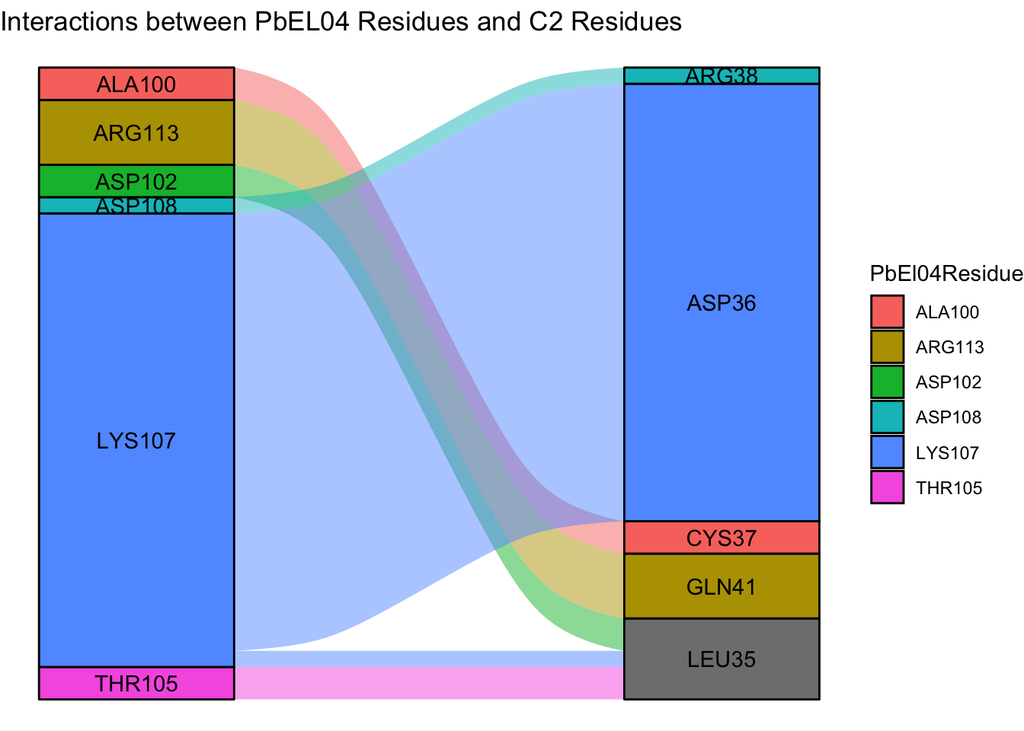

```r
#install.packages(c("tidyverse", "ggplot2", "alluvial", "ggalluvial"))
library(ggplot2)
library(alluvial)
library(ggalluvial)
library(tidyverse)
Alluvial.Plot.Test.1 <- read.csv("~/Desktop/Alluvial Plot Test 1.csv", header = TRUE)
View(Alluvial.Plot.Test.1)

grouped_data <- Alluvial.Plot.Test.1 %>%
  group_by(PbEl04Residue, C2Residue) %>%
  summarise(Freq = n())
#ggplot is the main function that renders the plot
ggplot(as.data.frame(grouped_data),
       aes(y = Freq,
         axis1 = PbEl04Residue,
         axis2 = C2Residue,)) +
geom_alluvium(aes(fill = PbEl04Residue)) +
  #geom_stratum receives a dataset of the horizontal
  #(x) and vertical (y) positions of the strata of an alluvial plot.
  #It plots rectangles for these strata (columns) of a provided width
  geom_stratum(aes(fill = PbEl04Residue)) +
  geom_text(stat = "stratum", aes(label = after_stat(stratum))) +
#The "strat = stratum" argument here references
#that the text present here is to be based on
#stratum (columns) regarding the grouped data data frame
  ggtitle("Interactions between PbEL04 Residues and C2 Residues") +
  theme_void()
```

```r
#HERE'S THE INFORMATION PROBIDED BY THE CHEAT SHEET
#1. Axis:
```

[output not shown]

Basic Alluvial Wide Format: Description: Example: loadpackages library(ggalluvial) basic ggplot gg <- ggplot(as.data.frame (UCBAdmissions), aes(y = Freq, axis1 = Gender, axis2 = Dept, axis3 = Admit)) add alluvium + geom_alluvium() add stratum + geom_stratum() add text + geom_text(stat = “stratum”, aes(label = paste(after_stat(stratum)))) add title + ggtitle(“YOUR TITLE GOES HERE”)

Change Colour: Description: Example: The border of Alluvium geom_alluvium(color=“red”) the border of the stratum geom_stratum(color=“blue”) the fill of the alluvium geom_alluvium(aes(fill=alluvium-variable)) geom_alluvium(aes(fill=stratum-variable)) geom_stratum(aes(fill=stratum-variable))

setting the different fills of alluvium and stratum can help analysts easily analyze the data from different aspects